# PROYECTO DE ANÁLISIS DE SUPERVIVENCIA

### Procedimientos almacenados

### Dimensiones

- DIM_EMPRESA

```sql
CREATE TABLE `DIM_EMPRESA` (
  `SK_EMPRESA` bigint(11) NOT NULL AUTO_INCREMENT,
  `COD_EMPRESA` varchar(20) CHARACTER SET utf8 COLLATE utf8_general_ci DEFAULT NULL,
  `EMPRESA` varchar(100) CHARACTER SET utf8 COLLATE utf8_general_ci DEFAULT NULL,
  `FECHA_CARGA` timestamp NOT NULL DEFAULT CURRENT_TIMESTAMP COMMENT 'Fecha en la que se realizo la carga' ,
  KEY `COD_EMPRESA` (`COD_EMPRESA`) USING CLUSTERED COLUMNSTORE,
  SHARD KEY `SK_EMPRESA` (`SK_EMPRESA`)
) ;

CREATE OR REPLACE PROCEDURE `CRG_DIM_EMPRESA`(VAR_SCHEMA varchar(10) CHARACTER SET utf8 COLLATE utf8_general_ci NULL) RETURNS void AS
DECLARE
    VAR_SQL VARCHAR(4000);
    VAR_ERROR VARCHAR(4000);
    VAR_DT_INICIO TIMESTAMP = CURRENT_TIMESTAMP;
BEGIN
START TRANSACTION;
    INSERT INTO CTR.LOG_PROCESO (MODULO, ETAPA,DT_FECHA_INICIO) VALUES ('DIMENSION',CONCAT('INICIO ',VAR_SCHEMA,'.CRG_DIM_EMPRESA'),VAR_DT_INICIO);
    COMMIT;

    VAR_SQL=CONCAT('DROP TABLE IF EXISTS ',VAR_SCHEMA,'.TMP1_EMPRESA');
     EXECUTE IMMEDIATE VAR_SQL;
    COMMIT;

    -- GUARDA EN UNA TABLA TEMPORAL LOS REGISTROS ACTUALIZADOS
    VAR_SQL=CONCAT('CREATE TABLE ',VAR_SCHEMA,'.TMP1_EMPRESA (KEY (SK_EMPRESA) USING CLUSTERED COLUMNSTORE)
    SELECT  R.SK_EMPRESA,R.COD_EMPRESA
    ,IF(NVL(P.NOMBRE,R.EMPRESA)=R.EMPRESA,R.EMPRESA,P.NOMBRE) EMPRESA
    ,IF(NVL(P.NOMBRE,R.EMPRESA)=R.EMPRESA
    ,R.FECHA_CARGA,CURRENT_TIMESTAMP) FECHA_CARGA
    FROM DWH.DIM_EMPRESA R
    LEFT JOIN ',VAR_SCHEMA,'.S3S_ARCGMC P ON R.COD_EMPRESA=P.NO_CIA
    ');
     EXECUTE IMMEDIATE VAR_SQL;
    COMMIT;

    -- ELIMINA LOS DATOS DE LA DIM
    VAR_SQL=CONCAT('TRUNCATE TABLE DWH.DIM_EMPRESA');
     EXECUTE IMMEDIATE VAR_SQL;
    COMMIT;

    -- INSERTA LOS DATOS DE LA TMP1 A LA DIM
    VAR_SQL=CONCAT('    INSERT INTO DWH.DIM_EMPRESA
    (SK_EMPRESA,COD_EMPRESA, EMPRESA,FECHA_CARGA)
    SELECT A.SK_EMPRESA,A.COD_EMPRESA, A.EMPRESA,A.FECHA_CARGA
    FROM ',VAR_SCHEMA,'.TMP1_EMPRESA A
    ');
     EXECUTE IMMEDIATE VAR_SQL;
    COMMIT;

    VAR_SQL=CONCAT('DROP TABLE IF EXISTS ',VAR_SCHEMA,'.TMP1_EMPRESA');
     EXECUTE IMMEDIATE VAR_SQL;
    COMMIT;

    -- INSERTA NUEVOS REGISTROS A LA DIM
    VAR_SQL=CONCAT('INSERT INTO DWH.DIM_EMPRESA
    (COD_EMPRESA, EMPRESA)
    SELECT A.NO_CIA,A.NOMBRE FROM ',VAR_SCHEMA,'.S3S_ARCGMC A
    LEFT JOIN DWH.DIM_EMPRESA B ON A.NO_CIA=B.COD_EMPRESA
    WHERE B.COD_EMPRESA IS NULL
    ');
     EXECUTE IMMEDIATE VAR_SQL;
    COMMIT;

END;
```

- DIM_TIPO_DOCUMENTO

```sql
CREATE TABLE `DIM_TIPO_DOCUMENTO` (
  `SK_TIPO_DOCUMENTO` bigint(11) NOT NULL AUTO_INCREMENT,
  `COD_EMPRESA` varchar(20) CHARACTER SET utf8 COLLATE utf8_general_ci DEFAULT NULL,
  `COD_TIPO_DOCUMENTO` varchar(20) CHARACTER SET utf8 COLLATE utf8_general_ci DEFAULT NULL,
  `TIPO_DOCUMENTO` varchar(100) CHARACTER SET utf8 COLLATE utf8_general_ci DEFAULT NULL,
  `FECHA_CARGA` timestamp NOT NULL DEFAULT CURRENT_TIMESTAMP COMMENT 'Fecha en la que se realizo la carga' ,
  KEY `COD_EMPRESA` (`COD_EMPRESA`,`COD_TIPO_DOCUMENTO`) USING CLUSTERED COLUMNSTORE,
  SHARD KEY `SK_TIPO_DOCUMENTO` (`SK_TIPO_DOCUMENTO`)
) ;

CREATE OR REPLACE PROCEDURE `CRG_DIM_TIPO_DOCUMENTO`(VAR_SCHEMA varchar(10) CHARACTER SET utf8 COLLATE utf8_general_ci NULL) RETURNS void AS
DECLARE
    VAR_SQL VARCHAR(4000);
    VAR_ERROR VARCHAR(4000);
    VAR_DT_INICIO TIMESTAMP = CURRENT_TIMESTAMP;
BEGIN
START TRANSACTION;
    INSERT INTO CTR.LOG_PROCESO (MODULO, ETAPA,DT_FECHA_INICIO) VALUES ('DIMENSION',CONCAT('INICIO ',VAR_SCHEMA,'.CRG_DIM_TIPO_DOCUMENTO'),VAR_DT_INICIO);
    COMMIT;


    -- GUARDA EN UNA TABLA TEMPORAL LOS REGISTROS ACTUALIZADOS
    VAR_SQL=CONCAT('
       UPDATE DWH.DIM_TIPO_DOCUMENTO  R
        INNER JOIN ',VAR_SCHEMA,'.S3S_FAC_DOCUMENTOS  P ON R.COD_EMPRESA=P.NO_CIA and R.COD_TIPO_DOCUMENTO=P.TIPO
        SET R.COD_TIPO_DOCUMENTO=P.TIPO,
        R.TIPO_DOCUMENTO=P.DESCRIPCION; ');
     EXECUTE IMMEDIATE VAR_SQL;
    COMMIT;



    -- INSERTA NUEVOS REGISTROS A LA DIM
    VAR_SQL=CONCAT('INSERT INTO DWH.DIM_TIPO_DOCUMENTO
    (COD_EMPRESA,COD_TIPO_DOCUMENTO,TIPO_DOCUMENTO)
    SELECT A.NO_CIA, A.TIPO, A.DESCRIPCION FROM ',VAR_SCHEMA,'.S3S_FAC_DOCUMENTOS A
    LEFT JOIN DWH.DIM_TIPO_DOCUMENTO B ON A.NO_CIA=B.COD_EMPRESA AND A.TIPO = B.COD_TIPO_DOCUMENTO
    WHERE B.COD_EMPRESA IS NULL;
    ');
     EXECUTE IMMEDIATE VAR_SQL;
    COMMIT;

END;
```

- DIM_VENDEDOR

```sql
CREATE TABLE `DIM_VENDEDOR` (
  `SK_VENDEDOR` bigint(11) NOT NULL AUTO_INCREMENT,
  `COD_EMPRESA` varchar(20) CHARACTER SET utf8 COLLATE utf8_general_ci DEFAULT NULL,
  `COD_VENDEDOR` varchar(20) CHARACTER SET utf8 COLLATE utf8_general_ci DEFAULT NULL,
  `COD_USUARIO` varchar(20) CHARACTER SET utf8 COLLATE utf8_general_ci DEFAULT NULL,
  `NOMBRE_VENDEDOR` varchar(100) CHARACTER SET utf8 COLLATE utf8_general_ci DEFAULT NULL,
  `FECHA_CARGA` timestamp NOT NULL DEFAULT CURRENT_TIMESTAMP COMMENT 'Fecha en la que se realizo la carga' ,
  `ESTADO` varchar(20) CHARACTER SET utf8 COLLATE utf8_general_ci DEFAULT NULL,
  KEY `COD_EMPRESA` (`COD_EMPRESA`,`COD_VENDEDOR`,`COD_USUARIO`) USING CLUSTERED COLUMNSTORE,
  SHARD KEY `SK_VENDEDOR` (`SK_VENDEDOR`)
) ;

CREATE OR REPLACE PROCEDURE `CRG_DIM_VENDEDOR`(VAR_SCHEMA varchar(10) CHARACTER SET utf8 COLLATE utf8_general_ci NULL) RETURNS void AS
DECLARE
    VAR_SQL VARCHAR(4000);
    VAR_ERROR VARCHAR(4000);
    VAR_DT_INICIO TIMESTAMP = CURRENT_TIMESTAMP;
BEGIN
START TRANSACTION;
    INSERT INTO CTR.LOG_PROCESO (MODULO, ETAPA,DT_FECHA_INICIO) VALUES ('DIMENSION',CONCAT('INICIO ',VAR_SCHEMA,'.CRG_DIM_VENDEDOR'),VAR_DT_INICIO);
    COMMIT;

    VAR_SQL=CONCAT('DROP TABLE IF EXISTS ',VAR_SCHEMA,'.TMP1_VENDEDOR');
     EXECUTE IMMEDIATE VAR_SQL;
    COMMIT;

    -- GUARDA EN UNA TABLA TEMPORAL LOS REGISTROS ACTUALIZADOS
    VAR_SQL=CONCAT('CREATE TABLE ',VAR_SCHEMA,'.TMP1_VENDEDOR (KEY (SK_VENDEDOR) USING CLUSTERED COLUMNSTORE)
            SELECT  R.SK_VENDEDOR,R.COD_EMPRESA,      R.COD_VENDEDOR,
    IF(NVL(P.SVVEUSUA  ,R.COD_USUARIO)=R.COD_USUARIO, R.COD_USUARIO , P.SVVEUSUA) COD_USUARIO
    ,IF(NVL(P.SVVENOMB,R.NOMBRE_VENDEDOR)=R.NOMBRE_VENDEDOR,R.NOMBRE_VENDEDOR,P.SVVENOMB) NOMBRE_VENDEDOR
    ,IF(NVL(P.SVVENOMB,R.NOMBRE_VENDEDOR)=R.NOMBRE_VENDEDOR,R.FECHA_CARGA,CURRENT_TIMESTAMP) FECHA_CARGA
    ,NVL(IF(NVL(O.ESTADO, R.ESTADO)=R.ESTADO, R.ESTADO, O.ESTADO), "NO DEFINIDO") ESTADO
    FROM DWH.DIM_VENDEDOR R
    LEFT JOIN ' ,VAR_SCHEMA,'.S3S_SVFVEND P ON R.COD_EMPRESA=P.NO_CIA and R.COD_VENDEDOR=P.SVVECODI
    LEFT JOIN ' ,VAR_SCHEMA,'.S3S_NOM_EMPLEADOS O ON O.NO_CIA = P.NO_CIA  AND O.NO_EMPLE =P.SVVECODI

    ');
     EXECUTE IMMEDIATE VAR_SQL;
    COMMIT;

    -- ELIMINA LOS DATOS DE LA DIM
    VAR_SQL=CONCAT('TRUNCATE TABLE DWH.DIM_VENDEDOR');
     EXECUTE IMMEDIATE VAR_SQL;
    COMMIT;

-- INSERTA LOS DATOS DE LA TMP1 A LA DIM
    VAR_SQL=CONCAT('INSERT INTO DWH.DIM_VENDEDOR
    (SK_VENDEDOR,COD_EMPRESA,COD_VENDEDOR,COD_USUARIO,NOMBRE_VENDEDOR,FECHA_CARGA, ESTADO)
    SELECT SK_VENDEDOR,COD_EMPRESA,COD_VENDEDOR,COD_USUARIO,NOMBRE_VENDEDOR,FECHA_CARGA, ESTADO
    FROM ' ,VAR_SCHEMA,'.TMP1_VENDEDOR ;
    ');
     EXECUTE IMMEDIATE VAR_SQL;
    COMMIT;

    VAR_SQL=CONCAT('DROP TABLE IF EXISTS ',VAR_SCHEMA,'.TMP1_VENDEDOR');
     EXECUTE IMMEDIATE VAR_SQL;
    COMMIT;

    -- INSERTA NUEVOS REGISTROS A LA DIM
    VAR_SQL=CONCAT(' INSERT INTO DWH.DIM_VENDEDOR
     (COD_EMPRESA,COD_VENDEDOR,COD_USUARIO,NOMBRE_VENDEDOR, ESTADO)
    SELECT A.NO_CIA, A.SVVECODI, A.SVVEUSUA, A.SVVENOMB , A.ESTADO
            FROM ( SELECT A.NO_CIA , A.SVVECODI  , A.SVVEUSUA , A.SVVENOMB  , NVL(B.ESTADO,"NO DEFINIDO") ESTADO
FROM ',VAR_SCHEMA,'.S3S_SVFVEND A
LEFT JOIN ',VAR_SCHEMA,'.S3S_NOM_EMPLEADOS B ON A.NO_CIA = B.NO_CIA AND B.NO_EMPLE = A.SVVECODI
                        ) A
    LEFT JOIN DWH.DIM_VENDEDOR B ON A.NO_CIA=B.COD_EMPRESA AND A.SVVECODI= B.COD_VENDEDOR
    WHERE B.COD_EMPRESA IS NULL;

    ');
     EXECUTE IMMEDIATE VAR_SQL;
    COMMIT;

END;
```

- DIM_TIPO_FINANCIACION

```sql
CREATE TABLE `DIM_TIPO_FINANCIACION` (
  `SK_TIPO_FINANCIACION` bigint(11) NOT NULL AUTO_INCREMENT,
  `COD_EMPRESA` varchar(20) CHARACTER SET utf8 COLLATE utf8_general_ci DEFAULT NULL,
  `COD_TIPO_FINANCIACION` varchar(20) CHARACTER SET utf8 COLLATE utf8_general_ci DEFAULT NULL,
  `TIPO_FINANCIACION` varchar(100) CHARACTER SET utf8 COLLATE utf8_general_ci DEFAULT NULL,
  `FECHA_CARGA` timestamp NOT NULL DEFAULT CURRENT_TIMESTAMP COMMENT 'Fecha en la que se realizo la carga' ,
  `GRUPO_ENTIDAD` varchar(100) CHARACTER SET utf8 COLLATE utf8_general_ci DEFAULT NULL,
  KEY `COD_EMPRESA` (`COD_EMPRESA`,`COD_TIPO_FINANCIACION`) USING CLUSTERED COLUMNSTORE,
  SHARD KEY `SK_TIPO_FINANCIACION` (`SK_TIPO_FINANCIACION`)
) ;

CREATE OR REPLACE PROCEDURE `CRG_DIM_TIPO_FINANCIACION`(VAR_SCHEMA varchar(10) CHARACTER SET utf8 COLLATE utf8_general_ci NULL) RETURNS void AS
DECLARE
    VAR_SQL VARCHAR(4000);
    VAR_ERROR VARCHAR(4000);
    VAR_DT_INICIO TIMESTAMP = CURRENT_TIMESTAMP;
BEGIN
START TRANSACTION;
    INSERT INTO CTR.LOG_PROCESO (MODULO, ETAPA,DT_FECHA_INICIO) VALUES ('DIMENSION',CONCAT('INICIO ',VAR_SCHEMA,'.CRG_DIM_TIPO_FINANCIACION'),VAR_DT_INICIO);
    COMMIT;

    VAR_SQL=CONCAT('DROP TABLE IF EXISTS ',VAR_SCHEMA,'.TMP1_TIPO_FINANCIACION');
     EXECUTE IMMEDIATE VAR_SQL;
    COMMIT;

    -- GUARDA EN UNA TABLA TEMPORAL LOS REGISTROS ACTUALIZADOS
    VAR_SQL=CONCAT('CREATE TABLE ',VAR_SCHEMA,'.TMP1_TIPO_FINANCIACION (KEY (SK_TIPO_FINANCIACION) USING CLUSTERED COLUMNSTORE)
        SELECT  R.SK_TIPO_FINANCIACION,R.COD_EMPRESA, R.COD_TIPO_FINANCIACION
    ,IF(NVL(P.ENTIDAD,R.TIPO_FINANCIACION)=R.TIPO_FINANCIACION,R.TIPO_FINANCIACION,P.ENTIDAD) TIPO_FINANCIACION
    ,IF(NVL(P.ENTIDAD,R.TIPO_FINANCIACION)=R.TIPO_FINANCIACION,R.FECHA_CARGA,CURRENT_TIMESTAMP) FECHA_CARGA
    ,NVL(IF(NVL(P.GRUPO_ENTIDAD,R.GRUPO_ENTIDAD)=R.GRUPO_ENTIDAD,R.GRUPO_ENTIDAD,P.GRUPO_ENTIDAD),"NO DEFINIDO") GRUPO_ENTIDAD
    FROM DWH.DIM_TIPO_FINANCIACION R
    LEFT JOIN DSA.S3S_ARCCTF P ON R.COD_EMPRESA=P.NO_CIA and R.COD_TIPO_FINANCIACION=P.TIPO AND NVL(P.ESTADO,"X") <>"I"
    ');
     EXECUTE IMMEDIATE VAR_SQL;
    COMMIT;

    -- ELIMINA LOS DATOS DE LA DIM
    VAR_SQL=CONCAT('TRUNCATE TABLE DWH.DIM_TIPO_FINANCIACION');
     EXECUTE IMMEDIATE VAR_SQL;
    COMMIT;

-- INSERTA LOS DATOS DE LA TMP1 A LA DIM
    VAR_SQL=CONCAT('INSERT INTO DWH.DIM_TIPO_FINANCIACION
    (SK_TIPO_FINANCIACION,COD_EMPRESA,COD_TIPO_FINANCIACION,TIPO_FINANCIACION,FECHA_CARGA, GRUPO_ENTIDAD)
    SELECT SK_TIPO_FINANCIACION,COD_EMPRESA,COD_TIPO_FINANCIACION,TIPO_FINANCIACION,FECHA_CARGA, GRUPO_ENTIDAD
    FROM ' ,VAR_SCHEMA,'.TMP1_TIPO_FINANCIACION ;
    ');
     EXECUTE IMMEDIATE VAR_SQL;
    COMMIT;

    VAR_SQL=CONCAT('DROP TABLE IF EXISTS ',VAR_SCHEMA,'.TMP1_TIPO_FINANCIACION');
     EXECUTE IMMEDIATE VAR_SQL;
    COMMIT;

    -- INSERTA NUEVOS REGISTROS A LA DIM
    VAR_SQL=CONCAT(' INSERT INTO DWH.DIM_TIPO_FINANCIACION
     (COD_EMPRESA,COD_TIPO_FINANCIACION,TIPO_FINANCIACION,GRUPO_ENTIDAD)
    SELECT A.NO_CIA, A.TIPO, A.ENTIDAD, NVL(A.GRUPO_ENTIDAD, "NO DEFINIDO") FROM DSA.S3S_ARCCTF A
    LEFT JOIN DWH.DIM_TIPO_FINANCIACION B ON A.NO_CIA=B.COD_EMPRESA AND A.TIPO = B.COD_TIPO_FINANCIACION
    WHERE B.COD_EMPRESA IS NULL AND  NVL(A.ESTADO,"X") <>"I" ;

    ');
     EXECUTE IMMEDIATE VAR_SQL;
    COMMIT;

END;
```

- DIM_FINANCIACION_VH

```sql
CREATE TABLE `DIM_FINANCIACION_VH` (
  `SK_FINANCIACION` bigint(11) NOT NULL AUTO_INCREMENT,
  `COD_FINANCIACION` varchar(20) CHARACTER SET utf8 COLLATE utf8_general_ci DEFAULT NULL,
  `FINANCIACION` varchar(100) CHARACTER SET utf8 COLLATE utf8_general_ci DEFAULT NULL,
  `FECHA_CARGA` timestamp NOT NULL DEFAULT CURRENT_TIMESTAMP COMMENT 'Fecha en la que se realizo la carga' ,
  KEY `COD_FINANCIACION` (`COD_FINANCIACION`) USING CLUSTERED COLUMNSTORE,
  SHARD KEY `SK_FINANCIACION` (`SK_FINANCIACION`)
);

INSERT INTO DIM_FINANCIACION_VH (COD_FINANCIACION,FINANCIACION) VALUES
     ('-1','NO DEFINIDO'),
     ('CA','CUOTA DE ALCANCE'),
     ('CD','CREDITO DIRECTO'),
     ('CT','CREDITO TRADICIONAL'),
     ('TSN','TSN'),
     ('CON','CONTADO');
```

- DIM_AGENCIA

```sql
CREATE TABLE `DIM_AGENCIA` (
  `SK_AGENCIA` bigint(11) NOT NULL AUTO_INCREMENT,
  `COD_EMPRESA` varchar(20) CHARACTER SET utf8 COLLATE utf8_general_ci DEFAULT NULL,
  `COD_AGENCIA` varchar(20) CHARACTER SET utf8 COLLATE utf8_general_ci DEFAULT NULL,
  `AGENCIA` varchar(100) CHARACTER SET utf8 COLLATE utf8_general_ci DEFAULT NULL,
  `PAIS` varchar(100) CHARACTER SET utf8 COLLATE utf8_general_ci DEFAULT NULL,
  `PROVINCIA` varchar(100) CHARACTER SET utf8 COLLATE utf8_general_ci DEFAULT NULL,
  `CIUDAD` varchar(100) CHARACTER SET utf8 COLLATE utf8_general_ci DEFAULT NULL,
  `FECHA_CARGA` timestamp NOT NULL DEFAULT CURRENT_TIMESTAMP COMMENT 'Fecha en la que se realizo la carga' ,
  KEY `COD_EMPRESA` (`COD_EMPRESA`,`COD_AGENCIA`) USING CLUSTERED COLUMNSTORE,
  SHARD KEY `SK_AGENCIA` (`SK_AGENCIA`)
) ;

CREATE OR REPLACE PROCEDURE `CRG_DIM_AGENCIA`(VAR_SCHEMA varchar(10) CHARACTER SET utf8 COLLATE utf8_general_ci NULL) RETURNS void AS
DECLARE
    VAR_SQL VARCHAR(4000);
    VAR_ERROR VARCHAR(4000);
    VAR_DT_INICIO TIMESTAMP = CURRENT_TIMESTAMP;
BEGIN
START TRANSACTION;
    INSERT INTO CTR.LOG_PROCESO (MODULO, ETAPA,DT_FECHA_INICIO) VALUES ('DIMENSION',CONCAT('INICIO ',VAR_SCHEMA,'.CRG_DIM_AGENCIA'),VAR_DT_INICIO);
    COMMIT;



    -- ACTUALIZA LOS REGISTROS EN LA DIM

    VAR_SQL=CONCAT('
        UPDATE DWH.DIM_AGENCIA  R
        INNER JOIN
        (SELECT A.NO_CIA, A. CODIGO, A.NOMBRE AS AGENCIA, DECODE(B.PAIS,01,"ECUADOR","NO DEFINIDO") AS PAIS, NVL(C.DESCRIPCION,"NO DEFINIDO") AS PROVINCIA,
                NVL(B.DESCRIPCION,"NO DEFINIDO") AS CIUDAD
                FROM ',VAR_SCHEMA,'.S3S_AGENCIAS A
                LEFT JOIN ',VAR_SCHEMA,'.S3S_ARCCCAN B ON A.CIUDAD = B.CANTON AND A.PROVINCIA = B.PROVINCIA
                LEFT JOIN ',VAR_SCHEMA,'.S3S_ARCCPRO C ON B.PROVINCIA = C.PROVINCIA)  P ON R.COD_EMPRESA=P.NO_CIA AND R.COD_AGENCIA = P.CODIGO
        SET R.AGENCIA=P.AGENCIA,
            R.PAIS=P.PAIS,
            R.PROVINCIA=P.PROVINCIA,
            R.CIUDAD=P.CIUDAD
        ;');
     EXECUTE IMMEDIATE VAR_SQL;
    COMMIT;

        -- INSERTA NUEVOS REGISTROS A LA DIM
    VAR_SQL=CONCAT('INSERT INTO DWH.DIM_AGENCIA
        (COD_EMPRESA, COD_AGENCIA, AGENCIA, PAIS, PROVINCIA, CIUDAD)
        SELECT A.NO_CIA,A.CODIGO,A.AGENCIA,A.PAIS,A.PROVINCIA,A.CIUDAD
        FROM
        (SELECT A.NO_CIA, A. CODIGO, A.NOMBRE AS AGENCIA, DECODE(B.PAIS,01,"ECUADOR","NO DEFINIDO") AS PAIS, NVL(C.DESCRIPCION,"NO DEFINIDO") AS PROVINCIA,
                NVL(B.DESCRIPCION,"NO DEFINIDO") AS CIUDAD
                FROM ',VAR_SCHEMA,'.S3S_AGENCIAS A
                LEFT JOIN ',VAR_SCHEMA,'.S3S_ARCCCAN B ON A.CIUDAD = B.CANTON AND A.PROVINCIA = B.PROVINCIA
                LEFT JOIN ',VAR_SCHEMA,'.S3S_ARCCPRO C ON B.PROVINCIA = C.PROVINCIA) A
        LEFT JOIN DWH.DIM_AGENCIA B ON A.NO_CIA=B.COD_EMPRESA AND A.CODIGO = B.COD_AGENCIA
        WHERE B.COD_EMPRESA IS NULL
        ');
     EXECUTE IMMEDIATE VAR_SQL;
    COMMIT;

END;
```

- DIM_LINEA_NEGOCIO

```sql
CREATE TABLE `DIM_LINEA_NEGOCIO` (
  `SK_LINEA_NEGOCIO` bigint(11) NOT NULL AUTO_INCREMENT,
  `COD_EMPRESA` varchar(20) CHARACTER SET utf8 COLLATE utf8_general_ci DEFAULT NULL,
  `COD_LINEA_NEGOCIO` varchar(20) CHARACTER SET utf8 COLLATE utf8_general_ci DEFAULT NULL,
  `LINEA_NEGOCIO` varchar(100) CHARACTER SET utf8 COLLATE utf8_general_ci DEFAULT NULL,
  `FECHA_CARGA` timestamp NOT NULL DEFAULT CURRENT_TIMESTAMP COMMENT 'Fecha en la que se realizo la carga' ,
  KEY `COD_EMPRESA` (`COD_EMPRESA`,`COD_LINEA_NEGOCIO`) USING CLUSTERED COLUMNSTORE,
  SHARD KEY `SK_LINEA_NEGOCIO` (`SK_LINEA_NEGOCIO`)
) ;

CREATE OR REPLACE PROCEDURE `CRG_DIM_LINEA_NEGOCIO`(VAR_SCHEMA varchar(10) CHARACTER SET utf8 COLLATE utf8_general_ci NULL) RETURNS void AS
DECLARE
    VAR_SQL VARCHAR(4000);
    VAR_ERROR VARCHAR(4000);
    VAR_DT_INICIO TIMESTAMP = CURRENT_TIMESTAMP;
BEGIN
START TRANSACTION;
    INSERT INTO CTR.LOG_PROCESO (MODULO, ETAPA,DT_FECHA_INICIO) VALUES ('DIMENSION',CONCAT('INICIO ',VAR_SCHEMA,'.CRG_DIM_LINEA_NEGOCIO'),VAR_DT_INICIO);
    COMMIT;

    VAR_SQL=CONCAT('
            UPDATE DWH.DIM_LINEA_NEGOCIO  R
            INNER JOIN (SELECT   A.NO_CIA, A.NO_LINEA, A.DESCRIPCION
                                        FROM ',VAR_SCHEMA,'.S3S_ARCJLI A
                                        UNION
                                        SELECT COD_EMPRESA, S3S_ID, NAME
                                        FROM ',VAR_SCHEMA,'.CRM_CB_LINEANEGOCIO WHERE COD_EMPRESA = "01" AND s3s_id = "ce")  P ON R.COD_EMPRESA=P.NO_CIA AND R.COD_LINEA_NEGOCIO = P.NO_LINEA
            SET R.LINEA_NEGOCIO =P.DESCRIPCION ;');
         EXECUTE IMMEDIATE VAR_SQL;
        COMMIT;


    -- INSERTA NUEVOS REGISTROS A LA DIM
    VAR_SQL=CONCAT('INSERT INTO DWH.DIM_LINEA_NEGOCIO
    (COD_EMPRESA, COD_LINEA_NEGOCIO, LINEA_NEGOCIO)
    SELECT A.NO_CIA, A.NO_LINEA, A.DESCRIPCION FROM (SELECT   A.NO_CIA, A.NO_LINEA, A.DESCRIPCION
                                                                                                FROM ',VAR_SCHEMA,'.S3S_ARCJLI A
                                                                                                UNION
                                                                                                SELECT COD_EMPRESA, S3S_ID, NAME
                                                                                                FROM ',VAR_SCHEMA,'.CRM_CB_LINEANEGOCIO WHERE COD_EMPRESA = "01" AND s3s_id = "ce") A
    LEFT JOIN DWH.DIM_LINEA_NEGOCIO B ON A.NO_CIA=B.COD_EMPRESA AND A.NO_LINEA = B.COD_LINEA_NEGOCIO
    WHERE B.COD_EMPRESA IS NULL
    ');
     EXECUTE IMMEDIATE VAR_SQL;
    COMMIT;

END;
```

- DIM_VEHICULO

```sql
CREATE TABLE `DIM_VEHICULO` (
  `SK_VEHICULO` bigint(11) NOT NULL AUTO_INCREMENT,
  `COD_EMPRESA` varchar(20) CHARACTER SET utf8 COLLATE utf8_general_ci DEFAULT NULL,
  `COD_LINEA_NEGOCIO` varchar(20) CHARACTER SET utf8 COLLATE utf8_general_ci DEFAULT NULL,
  `CHASIS` varchar(30) CHARACTER SET utf8 COLLATE utf8_general_ci DEFAULT NULL,
  `PLACA` varchar(20) CHARACTER SET utf8 COLLATE utf8_general_ci DEFAULT NULL,
  `MARCA` varchar(100) CHARACTER SET utf8 COLLATE utf8_general_ci DEFAULT NULL,
  `ANIO_VEHICULO` varchar(100) CHARACTER SET utf8 COLLATE utf8_general_ci DEFAULT NULL,
  `SVMAMASTER` varchar(100) CHARACTER SET utf8 COLLATE utf8_general_ci DEFAULT NULL,
  `SFX` varchar(100) CHARACTER SET utf8 COLLATE utf8_general_ci DEFAULT NULL,
  `MODELO` varchar(100) CHARACTER SET utf8 COLLATE utf8_general_ci DEFAULT NULL,
  `FECHA_CARGA` timestamp NOT NULL DEFAULT CURRENT_TIMESTAMP COMMENT 'Fecha en la que se realizo la carga' ,
  `TIPO_VEHICULO` varchar(200) CHARACTER SET utf8 COLLATE utf8_general_ci DEFAULT NULL,
  `COLOR` varchar(100) CHARACTER SET utf8 COLLATE utf8_general_ci DEFAULT NULL,
  `CLASE` varchar(100) CHARACTER SET utf8 COLLATE utf8_general_ci DEFAULT NULL,
  `FAMILIA` varchar(30) CHARACTER SET utf8 COLLATE utf8_general_ci DEFAULT NULL,
  KEY `SK_VEHICULO` (`COD_EMPRESA`,`COD_LINEA_NEGOCIO`,`CHASIS`) USING CLUSTERED COLUMNSTORE,
  SHARD KEY `SK_VEHICULO_2` (`SK_VEHICULO`)
) ;

CREATE OR REPLACE PROCEDURE `CRG_DIM_VEHICULO`(VAR_SCHEMA varchar(10) CHARACTER SET utf8 COLLATE utf8_general_ci NULL) RETURNS void AS
DECLARE
    VAR_SQL VARCHAR(4000);
    VAR_ERROR VARCHAR(4000);
    VAR_DT_INICIO TIMESTAMP = CURRENT_TIMESTAMP;
BEGIN
START TRANSACTION;
    INSERT INTO CTR.LOG_PROCESO (MODULO, ETAPA,DT_FECHA_INICIO) VALUES ('DIMENSION',CONCAT('INICIO ',VAR_SCHEMA,'.CRG_DIM_VEHICULO'),VAR_DT_INICIO);
    COMMIT;


VAR_SQL=CONCAT('UPDATE DWH.DIM_VEHICULO R
                LEFT JOIN ' ,VAR_SCHEMA,'.S3S_CAT_VEHICULO P ON R.COD_EMPRESA = P.COD_EMPRESA AND R.COD_LINEA_NEGOCIO = P.COD_LINEA_NEGOCIO AND R.CHASIS = P.CHASIS
        SET     R.FECHA_CARGA = IF(NVL(P.PLACA,R.PLACA)=R.PLACA,R.FECHA_CARGA,CURRENT_TIMESTAMP)
                , R.PLACA = NVL(IF(NVL(P.PLACA,R.PLACA)=R.PLACA,R.PLACA,P.PLACA), "NO DEFINIDO")
                , R.MARCA = NVL(IF(NVL(P.MARCA,R.MARCA)=R.MARCA,R.MARCA,P.MARCA), "NO DEFINIDO")
                , R.ANIO_VEHICULO = NVL(IF(NVL(P.ANIO_VEHICULO,R.ANIO_VEHICULO)=R.ANIO_VEHICULO,R.ANIO_VEHICULO,P.ANIO_VEHICULO), "NO DEFINIDO")
                , R.SVMAMASTER = NVL(IF(NVL(P.SVMAMASTER,R.SVMAMASTER)=R.SVMAMASTER,R.SVMAMASTER,P.SVMAMASTER), "NO DEFINIDO")
                , R.SFX = NVL(IF(NVL(P.SFX,R.SFX)=R.SFX,R.SFX,P.SFX), "NO DEFINIDO")
                , R.MODELO = NVL(IF(NVL(P.MODELO,R.MODELO)=R.MODELO,R.MODELO,P.MODELO), "NO DEFINIDO")
                , R.TIPO_VEHICULO = NVL(IF(NVL(P.TIPO_VEHICULO,R.TIPO_VEHICULO)=R.TIPO_VEHICULO,R.TIPO_VEHICULO,P.TIPO_VEHICULO), "NO DEFINIDO")
                , R.COLOR = NVL(IF(NVL(P.COLOR,R.COLOR)=R.COLOR,R.COLOR,P.COLOR), "NO DEFINIDO")
                , R.CLASE = NVL(IF(NVL(P.CLASE,R.CLASE)=R.CLASE,R.CLASE,P.CLASE), "NO DEFINIDO")
                , R.FAMILIA = NVL(IF(NVL(P.FAMILIA,R.FAMILIA)=R.FAMILIA,R.FAMILIA,P.FAMILIA), "NO DEFINIDO")
    ');
     EXECUTE IMMEDIATE VAR_SQL;
    COMMIT;

        -- INSERTA NUEVOS REGISTROS A LA DIM
    VAR_SQL=CONCAT('INSERT INTO DWH.DIM_VEHICULO
        ( COD_EMPRESA, COD_LINEA_NEGOCIO, CHASIS, PLACA, MARCA,ANIO_VEHICULO,SVMAMASTER ,SFX, MODELO, TIPO_VEHICULO, COLOR, CLASE,FAMILIA)
        SELECT  A.COD_EMPRESA, A.COD_LINEA_NEGOCIO, A.CHASIS, NVL(A.PLACA,"NO DEFINIDO"), NVL(A.MARCA,"NO DEFINIDO"),
        NVL(A.ANIO_VEHICULO,"NO DEFINIDO"), NVL(A.SVMAMASTER,"NO DEFINIDO"),NVL(A.SFX,"NO DEFINIDO"), NVL(A.MODELO, "NO DEFINIDO"),
        NVL(A.TIPO_VEHICULO, "NO DEFINIDO"), NVL(A.COLOR, "NO DEFINIDO"), NVL(A.CLASE, "NO DEFINIDO") , NVL(A.FAMILIA, "NO DEFINIDO")
        FROM DSA.S3S_CAT_VEHICULO A
        LEFT JOIN DWH.DIM_VEHICULO B ON A.COD_LINEA_NEGOCIO = B.COD_LINEA_NEGOCIO AND A.COD_EMPRESA = B.COD_EMPRESA AND A.CHASIS = B.CHASIS
        WHERE B.COD_EMPRESA IS NULL
        ');
     EXECUTE IMMEDIATE VAR_SQL;
    COMMIT;

END;
```

- DIM_TECNICO_ASESOR

```sql
CREATE TABLE `DIM_TECNICO_ASESOR` (
  `SK_TECNICO_ASESOR` bigint(11) NOT NULL AUTO_INCREMENT,
  `COD_EMPRESA` varchar(20) CHARACTER SET utf8 COLLATE utf8_general_ci DEFAULT NULL,
  `COD_TECNICO_ASESOR` varchar(20) CHARACTER SET utf8 COLLATE utf8_general_ci DEFAULT NULL,
  `TECNICO_ASESOR` varchar(100) CHARACTER SET utf8 COLLATE utf8_general_ci DEFAULT NULL,
  `FECHA_CARGA` timestamp NOT NULL DEFAULT CURRENT_TIMESTAMP COMMENT 'Fecha en la que se realizo la carga' ,
  `ESTADO` varchar(20) CHARACTER SET utf8 COLLATE utf8_general_ci DEFAULT NULL,
  KEY `COD_EMPRESA` (`COD_EMPRESA`,`COD_TECNICO_ASESOR`) USING CLUSTERED COLUMNSTORE,
  SHARD KEY `SK_TECNICO_ASESOR` (`SK_TECNICO_ASESOR`)
) ;

CREATE OR REPLACE PROCEDURE `CRG_DIM_TECNICO_ASESOR`(VAR_SCHEMA varchar(10) CHARACTER SET utf8 COLLATE utf8_general_ci NULL) RETURNS void AS
DECLARE
    VAR_SQL VARCHAR(4000);
    VAR_ERROR VARCHAR(4000);
    VAR_DT_INICIO TIMESTAMP = CURRENT_TIMESTAMP;
BEGIN
START TRANSACTION;
    INSERT INTO CTR.LOG_PROCESO (MODULO, ETAPA,DT_FECHA_INICIO) VALUES ('DIMENSION',CONCAT('INICIO ',VAR_SCHEMA,'.CRG_DIM_TECNICO_ASESOR'),VAR_DT_INICIO);
    COMMIT;

    VAR_SQL=CONCAT('DROP TABLE IF EXISTS ',VAR_SCHEMA,'.TMP1_TECNICO_ASESOR');
     EXECUTE IMMEDIATE VAR_SQL;
    COMMIT;

    -- GUARDA EN UNA TABLA TEMPORAL LOS REGISTROS ACTUALIZADOS
    VAR_SQL=CONCAT('CREATE TABLE ',VAR_SCHEMA,'.TMP1_TECNICO_ASESOR (KEY (SK_TECNICO_ASESOR) USING CLUSTERED COLUMNSTORE)
    SELECT  R.SK_TECNICO_ASESOR,R.COD_EMPRESA, R.COD_TECNICO_ASESOR
    ,IF(NVL(P.NOMBRE,R.TECNICO_ASESOR)=R.TECNICO_ASESOR,R.TECNICO_ASESOR,P.NOMBRE) TECNICO_ASESOR
    ,IF(NVL(P.NOMBRE,R.TECNICO_ASESOR)=R.TECNICO_ASESOR,R.FECHA_CARGA,CURRENT_TIMESTAMP) FECHA_CARGA
    ,NVL(IF(NVL(P.ESTADO,R.ESTADO)=R.ESTADO, R.ESTADO, P.ESTADO), "NO DEFINIDO") ESTADO
    FROM DWH.DIM_TECNICO_ASESOR R
    LEFT JOIN ',VAR_SCHEMA,'.S3S_SE_TECNIASESOR P ON R.COD_EMPRESA=P.NO_CIA AND R.COD_TECNICO_ASESOR = P.TECNIASESOR_ID
     ;
    ');
     EXECUTE IMMEDIATE VAR_SQL;
    COMMIT;

    -- ELIMINA LOS DATOS DE LA DIM
    VAR_SQL=CONCAT('TRUNCATE TABLE DWH.DIM_TECNICO_ASESOR');
     EXECUTE IMMEDIATE VAR_SQL;
    COMMIT;

    -- INSERTA LOS DATOS DE LA TMP1 A LA DIM
    VAR_SQL=CONCAT('INSERT INTO DWH.DIM_TECNICO_ASESOR
    (SK_TECNICO_ASESOR,COD_EMPRESA, COD_TECNICO_ASESOR,TECNICO_ASESOR,FECHA_CARGA, ESTADO)
    SELECT A.SK_TECNICO_ASESOR,A.COD_EMPRESA, A.COD_TECNICO_ASESOR, A.TECNICO_ASESOR,A.FECHA_CARGA, ESTADO
    FROM ',VAR_SCHEMA,'.TMP1_TECNICO_ASESOR A
    ');
     EXECUTE IMMEDIATE VAR_SQL;
    COMMIT;

    VAR_SQL=CONCAT('DROP TABLE IF EXISTS ',VAR_SCHEMA,'.TMP1_TECNICO_ASESOR');
     EXECUTE IMMEDIATE VAR_SQL;
    COMMIT;

    -- INSERTA NUEVOS REGISTROS A LA DIM
    VAR_SQL=CONCAT('INSERT INTO DWH.DIM_TECNICO_ASESOR
    (COD_EMPRESA, COD_TECNICO_ASESOR, TECNICO_ASESOR, ESTADO)
    SELECT A.NO_CIA, A.TECNIASESOR_ID, A.NOMBRE, NVL(A.ESTADO, "NO DEFINIDO") ESTADO
FROM ',VAR_SCHEMA,'.S3S_SE_TECNIASESOR A
    LEFT JOIN DWH.DIM_TECNICO_ASESOR B ON A.NO_CIA=B.COD_EMPRESA AND A.TECNIASESOR_ID = B.COD_TECNICO_ASESOR
    WHERE B.COD_EMPRESA IS NULL
    ');
     EXECUTE IMMEDIATE VAR_SQL;
    COMMIT;

END;
```

### Tabla de Hechos

- FC_VENTA_VS_MANTENIMIENTO

```sql
CREATE TABLE `FC_VENTA_VS_MANTENIMIENTO` (
  `SK_EMPRESA` bigint(20) DEFAULT 1,
  `SK_FECHA` bigint(20) DEFAULT 19700101,
  `SK_FACTURA` text CHARACTER SET utf8 COLLATE utf8_general_ci,
  `NO_FISICO` text CHARACTER SET utf8 COLLATE utf8_general_ci,
  `SK_TIPO_DOCUMENTO` bigint(11) DEFAULT 11,
  `SK_VENDEDOR` bigint(11) DEFAULT NULL,
  `SK_TIPO_FINANCIACION` bigint(11) DEFAULT 1,
  `SK_AGENCIA` bigint(11) DEFAULT 1,
  `SK_AGENCIA_FACTURA` bigint(11) DEFAULT 1,
  `SK_LINEA_NEGOCIO` bigint(11) DEFAULT 1,
  `SK_FECHA_SALIDA` bigint(20) DEFAULT 19700101,
  `SK_VEHICULO` bigint(11) DEFAULT 1,
  `SK_AGENCIA_MNT1` bigint(11) DEFAULT 1,
  `SK_TECNICO_ASESOR1` bigint(11) DEFAULT 1,
  `MANTENIMIENTO_1000` decimal(18,0) DEFAULT NULL,
  `SK_FECHA_MANTENIMIENTO_1000` bigint(20) DEFAULT 19700101,
  `SK_AGENCIA_MNT5` bigint(11) DEFAULT 1,
  `SK_TECNICO_ASESOR5` bigint(11) DEFAULT 1,
  `MANTENIMIENTO_5000` decimal(18,0) DEFAULT NULL,
  `SK_FECHA_MANTENIMIENTO_5000` bigint(20) DEFAULT 19700101,
  `SK_AGENCIA_MNT10` bigint(11) DEFAULT 1,
  `SK_TECNICO_ASESOR10` bigint(11) DEFAULT 1,
  `MANTENIMIENTO_10000` decimal(18,0) DEFAULT NULL,
  `SK_FECHA_MANTENIMIENTO_10000` bigint(20) DEFAULT 19700101,
  `SK_FINANCIACION` bigint(20) DEFAULT NULL,
  KEY `FC_VENTAS_NUEVOS_EXONERADOS_MANTENIMIENTOS` (`SK_FECHA`,`SK_FACTURA`,`SK_VEHICULO`) USING CLUSTERED COLUMNSTORE
  , SHARD KEY ()
) ;

CREATE OR REPLACE PROCEDURE `CRG_FC_VENTA_VS_MANTENIMIENTO`(VAR_SCHEMA varchar(10) CHARACTER SET utf8 COLLATE utf8_general_ci NULL, VAR_EMPRESA varchar(20) CHARACTER SET utf8 COLLATE utf8_general_ci NULL, VAR_FECHA_INICIO date NULL, VAR_FECHA_FIN date NULL, VAR_LINEA_NEGOCIO_NUEVOS varchar(20) CHARACTER SET utf8 COLLATE utf8_general_ci NULL, VAR_LINEA_NEGOCIO_EXONERADOS varchar(20) CHARACTER SET utf8 COLLATE utf8_general_ci NULL, VAR_LINEA_NEGOCIO_MNT varchar(20) CHARACTER SET utf8 COLLATE utf8_general_ci NULL) RETURNS void AS
DECLARE
    VAR_SQL VARCHAR(8000);
    VAR_ERROR VARCHAR(4000);
    VAR_DT_INICIO TIMESTAMP = CURRENT_TIMESTAMP;
BEGIN
START TRANSACTION;
INSERT INTO CTR.LOG_PROCESO (MODULO, ETAPA,DT_FECHA_INICIO) VALUES ('TABLA DE HECHOS',CONCAT('INICIO ',VAR_SCHEMA,'.CRG_FC_VENTA_VS_MANTENIMIENTO'),VAR_DT_INICIO);
COMMIT;

VAR_SQL=CONCAT('DROP TABLE IF EXISTS ',VAR_SCHEMA,'.TMP_VENTAS_NUEVOS_EXONERADOS');
EXECUTE IMMEDIATE VAR_SQL;
COMMIT;

VAR_SQL=CONCAT('DROP TABLE IF EXISTS ',VAR_SCHEMA,'.TMP_VENTA_MANTENIMIENTO');
EXECUTE IMMEDIATE VAR_SQL;
COMMIT;

/*Descripción: Creación de la tabla temporal de las ventas efectivas en las líneas de negocios nuevos y exonerados exluyendo a los clientes
*   CARLOS LARREA Y COMERCIAL HIDROVO*/

VAR_SQL=CONCAT(' CREATE TABLE DSA.TMP_VENTAS_NUEVOS_EXONERADOS (KEY (NO_FACTU,CHASIS) USING CLUSTERED COLUMNSTORE)
                    SELECT
                            AA.FECHA , AA.NO_FACTU , AA.NO_FISICO , AA.TIPO_DOC , AA.NO_VENDEDOR
                            , BB.CHASIS
                            , AA.LINEA , AA.NO_PEDIDO
                            , NVL(AA.CENTRO_ORIGEN,AA.CENTROD) COD_AGENCIA
                            , AA.CENTROD COD_AGENCIA_FACTURA
                            , AA.NO_CIA COD_EMPRESA
                            , AA.LINEA_NEGOCIO
                            , AA.FECHA_SALIDA
                            , CASE WHEN (AA.LINEA IN ("CY", "C8", "C1", "C2", "C3", "C4", "C5", "C6", "C7", "C9", "D1")) THEN "TSN"
                                        WHEN ((I.SALDO_FINANCIAR = 0) AND (I.CUOTA_DE_ALCANCE = 0)) THEN "CON"
                                        WHEN ((I.SALDO_FINANCIAR > 0) AND (AA.LINEA  = "CB")) THEN "CD"
                                        WHEN ((I.SALDO_FINANCIAR = 0) AND (I.CUOTA_DE_ALCANCE > 0) AND (AA.LINEA  = "CB")) THEN "CA"
                                        WHEN (AA.LINEA  = "SV") THEN "CA"
                                        WHEN (((I.CUOTA_DE_ALCANCE > 0) OR (I.SALDO_FINANCIAR= 0)) AND (AA.LINEA  <> "CB")) THEN "CT"
                                        WHEN (AA.LINEA  = "VE") THEN "CD"
                            ELSE "CT" END AS COD_FINANCIACION
                    FROM
                            ',VAR_SCHEMA,'.S3S_FAC_VENTAS_CAB AA
                            INNER JOIN ',VAR_SCHEMA,'.S3S_FAC_VENTAS_VEHICULOS BB ON AA.NO_CIA =BB.NO_CIA AND AA.RUTA =BB.RUTA AND AA.TIPO_DOC =BB.TIPO_DOC AND AA.NO_FACTU =BB.NO_FACTU
                            INNER JOIN ',VAR_SCHEMA,'.S3S_SVFCOTI I ON  AA.CENTROD = I.CENTRO AND AA.NO_PEDIDO = I.NUMERO_COTIZACION AND I.SVLICODI = AA.LINEA_NEGOCIO  AND AA.NO_CIA = I.NO_CIA
                    WHERE
                            AA.NO_CIA = "',VAR_EMPRESA,'"
                            AND AA.LINEA_NEGOCIO = "',VAR_LINEA_NEGOCIO_NUEVOS,'"
                            AND NVL(AA.IND_ANU_DEV,"X")<>"A"
                            AND DATE(AA.FECHA) BETWEEN "',VAR_FECHA_INICIO,'" AND "',VAR_FECHA_FIN,'"
                            AND AA.NO_CLIENTE NOT IN (69157,186117,20781,23437,63323)
                ');
EXECUTE IMMEDIATE VAR_SQL;
COMMIT;

VAR_SQL=CONCAT('INSERT INTO ',VAR_SCHEMA,'.TMP_VENTAS_NUEVOS_EXONERADOS
                    SELECT
                            AA.FECHA
                            , AA.NO_FACTU
                            , AA.NO_FISICO
                            , AA.TIPO_DOC , AA.NO_VENDEDOR
                            , BB.CHASIS
                            , AA.LINEA , AA.NO_PEDIDO
                            , NVL(AA.CENTRO_ORIGEN,AA.CENTROD) COD_AGENCIA
                            , AA.CENTROD COD_AGENCIA_FACTURA
                            , AA.NO_CIA COD_EMPRESA
                            , AA.LINEA_NEGOCIO
                            , AA.FECHA_SALIDA
                            , CASE WHEN (AA.LINEA IN ("CY", "C8", "C1", "C2", "C3", "C4", "C5", "C6", "C7", "C9", "D1")) THEN "TSN"
                                        WHEN ((I.SALDO_FINANCIAR = 0) AND (I.CUOTA_DE_ALCANCE = 0)) THEN "CON"
                                        WHEN ((I.SALDO_FINANCIAR > 0) AND (AA.LINEA  = "CB")) THEN "CD"
                                        WHEN ((I.SALDO_FINANCIAR = 0) AND (I.CUOTA_DE_ALCANCE > 0) AND (AA.LINEA  = "CB")) THEN "CA"
                                        WHEN (AA.LINEA  = "SV") THEN "CA"
                                        WHEN (((I.CUOTA_DE_ALCANCE > 0) OR (I.SALDO_FINANCIAR= 0)) AND (AA.LINEA  <> "CB")) THEN "CT"
                                        WHEN (AA.LINEA  = "VE") THEN "CD"
                                ELSE "CT" END AS COD_FINANCIACION
                    FROM
                            ',VAR_SCHEMA,'.S3S_FAC_VENTAS_CAB AA
                            INNER JOIN ',VAR_SCHEMA,'.S3S_FAC_VENTAS_VEHICULOS BB ON AA.NO_CIA =BB.NO_CIA AND BB.RUTA =AA.RUTA AND BB.TIPO_DOC =AA.TIPO_DOC AND BB.NO_FACTU =AA.NO_FACTU
                            INNER JOIN ',VAR_SCHEMA,'.S3S_SVFCOTI I ON  AA.CENTROD = I.CENTRO AND AA.NO_PEDIDO = I.NUMERO_COTIZACION AND I.SVLICODI = AA.LINEA_NEGOCIO  AND AA.NO_CIA = I.NO_CIA
                    WHERE
                            AA.NO_CIA = "',VAR_EMPRESA,'"
                            AND AA.LINEA_NEGOCIO = "',VAR_LINEA_NEGOCIO_EXONERADOS,'"
                            AND NVL(AA.IND_ANU_DEV,"X")<> "A"
                            AND AA.TIPO_DOC  IN ("EX","NE")
                            AND DATE(AA.FECHA) BETWEEN "',VAR_FECHA_INICIO,'"   AND "',VAR_FECHA_FIN,'"
                            AND AA.NO_CLIENTE NOT IN (69157,186117,20781,23437,63323)
                    ');
EXECUTE IMMEDIATE VAR_SQL;
COMMIT;
```

```sql
-- Descripción: Creación de la tabla temporal de las ordenes creadas de los vehículos que ingresan al taller a mantenimiento de los  1000, 5000, 10000 km

VAR_SQL=CONCAT('CREATE TABLE ',VAR_SCHEMA,'.TMP_VENTA_MANTENIMIENTO (KEY (CHASIS) USING CLUSTERED COLUMNSTORE)
                    SELECT
                            T.*
                            , T1.CODIGO AS AGENCIA_1
                            , T1.COD_TECNICO_ASESOR AS COD_TECNICO_ASESOR1
                            , T1.KM_RELACIONADO AS K1
                            , T1.FECHA_FACTURA FECHA_FACTURA_K1
                            , T2.CODIGO AS AGENCIA_5
                            , T2.COD_TECNICO_ASESOR AS COD_TECNICO_ASESOR5
                            , T2.KM_RELACIONADO AS K5
                            , T2.FECHA_FACTURA FECHA_FACTURA_K5
                            , T3.CODIGO AS AGENCIA_10
                            , T3.COD_TECNICO_ASESOR AS COD_TECNICO_ASESOR10
                            , T3.KM_RELACIONADO AS K10
                            , T3.FECHA_FACTURA FECHA_FACTURA_K10
                    FROM
                            ',VAR_SCHEMA,'.TMP_VENTAS_NUEVOS_EXONERADOS  T
                            LEFT JOIN (
                                                    SELECT
                                                            B.CHASIS_NO  , A.KILOMETRAJE, A.CODIGO
                                                            , A.TECNIASESOR_ID COD_TECNICO_ASESOR
                                                            , (D.KM_RELACIONADO) KM_RELACIONADO
                                                            , A.FECHA_CIERRE FECHA_FACTURA
                                                    FROM
                                                            ',VAR_SCHEMA,'.S3S_SE_ORDENREP A
                                                            LEFT JOIN ',VAR_SCHEMA,'.S3S_SE_VEHICULOS B ON A.NO_CIA = B.NO_CIA AND  A.NUMCBS = B.NUMCBS
                                                            LEFT JOIN ',VAR_SCHEMA,'.S3S_SE_TRABORDEN C ON A.NO_CIA = C.NO_CIA AND A.CODIGO = C.CODIGO AND A.ORDENREP_ID = C.ORDENREP_ID
                                                            LEFT JOIN ',VAR_SCHEMA,'.S3S_SE_MENUSERV3 D ON C.NO_CIA = D.NO_CIA AND C.CODSERV1 = D.CODSERV1 AND C.CODSERV2 = D.CODSERV2 AND C.CODSERV3 = D.CODSERV3
                                                            LEFT JOIN ',VAR_SCHEMA,'.S3S_SE_ORDENREP_NC NC ON NC.NO_CIA = A.NO_CIA AND A.ORDENREP_ID = NC.ORDENREP_ID_ORIGEN
                                                    WHERE
                                                            A.NO_CIA = "',VAR_EMPRESA,'"
                                                            AND A.LINEA_NEGOCIO = "',VAR_LINEA_NEGOCIO_MNT,'"
                                                            AND A.ESTADO_ID in ("85","90")
                                                            AND D.KM_RELACIONADO = 1000
                                                            AND NC.ORDENREP_ID_ORIGEN IS NULL
                                                ) T1  ON T1.CHASIS_NO = T.CHASIS AND YEAR(T1.FECHA_FACTURA) >= YEAR(T.FECHA)
                            LEFT JOIN (
                                                    SELECT
                                                            B.CHASIS_NO , A.KILOMETRAJE, A.CODIGO
                                                            , A.TECNIASESOR_ID COD_TECNICO_ASESOR
                                                            , NVL(A.FECHA_FACTURA,A.FECHA_CIERRE) FECHA_FACTURA
                                                            , (D.KM_RELACIONADO) KM_RELACIONADO
                                                    FROM
                                                            ',VAR_SCHEMA,'.S3S_SE_ORDENREP A
                                                            LEFT JOIN ',VAR_SCHEMA,'.S3S_SE_VEHICULOS B ON A.NO_CIA = B.NO_CIA AND  A.NUMCBS = B.NUMCBS
                                                            LEFT JOIN ',VAR_SCHEMA,'.S3S_SE_TRABORDEN C ON A.NO_CIA = C.NO_CIA AND A.CODIGO = C.CODIGO AND A.ORDENREP_ID = C.ORDENREP_ID
                                                            LEFT JOIN ',VAR_SCHEMA,'.S3S_SE_MENUSERV3 D ON C.NO_CIA = D.NO_CIA AND C.CODSERV1 = D.CODSERV1 AND C.CODSERV2 = D.CODSERV2 AND C.CODSERV3 = D.CODSERV3
                                                            LEFT JOIN ',VAR_SCHEMA,'.S3S_SE_ORDENREP_NC NC ON NC.NO_CIA = A.NO_CIA AND A.ORDENREP_ID = NC.ORDENREP_ID_ORIGEN
                                                    WHERE
                                                            A.NO_CIA = "',VAR_EMPRESA,'"
                                                            AND A.LINEA_NEGOCIO = "',VAR_LINEA_NEGOCIO_MNT,'"
                                                            AND A.ESTADO_ID in ("85","90")
                                                            AND D.KM_RELACIONADO = 5000
                                                            AND NC.ORDENREP_ID_ORIGEN IS NULL
                                                ) T2  ON T2.CHASIS_NO = T.CHASIS
                            LEFT JOIN (
                                                    SELECT
                                                            B.CHASIS_NO , A.KILOMETRAJE, A.CODIGO
                                                            , A.TECNIASESOR_ID COD_TECNICO_ASESOR
                                                            , NVL(A.FECHA_FACTURA,A.FECHA_CIERRE) FECHA_FACTURA
                                                            , (D.KM_RELACIONADO) KM_RELACIONADO
                                                    FROM
                                                            ',VAR_SCHEMA,'.S3S_SE_ORDENREP A
                                                            LEFT JOIN ',VAR_SCHEMA,'.S3S_SE_VEHICULOS B ON A.NO_CIA = B.NO_CIA AND  A.NUMCBS = B.NUMCBS
                                                            LEFT JOIN ',VAR_SCHEMA,'.S3S_SE_TRABORDEN C ON A.NO_CIA = C.NO_CIA AND A.CODIGO = C.CODIGO AND A.ORDENREP_ID = C.ORDENREP_ID
                                                            LEFT JOIN ',VAR_SCHEMA,'.S3S_SE_MENUSERV3 D ON C.NO_CIA = D.NO_CIA AND C.CODSERV1 = D.CODSERV1 AND C.CODSERV2 = D.CODSERV2 AND C.CODSERV3 = D.CODSERV3
                                                            LEFT JOIN ',VAR_SCHEMA,'.S3S_SE_ORDENREP_NC NC ON NC.NO_CIA = A.NO_CIA AND A.ORDENREP_ID = NC.ORDENREP_ID_ORIGEN
                                                    WHERE
                                                            A.NO_CIA = "',VAR_EMPRESA,'"
                                                            AND A.LINEA_NEGOCIO = "',VAR_LINEA_NEGOCIO_MNT,'"
                                                            AND A.ESTADO_ID in ("85","90")
                                                            AND D.KM_RELACIONADO = 10000
                                                            AND NC.ORDENREP_ID_ORIGEN IS NULL
                                                ) T3  ON T3.CHASIS_NO = T.CHASIS
                    ');
EXECUTE IMMEDIATE VAR_SQL;
COMMIT;
```

```sql
VAR_SQL=CONCAT('DELETE FROM DWH.FC_VENTA_VS_MANTENIMIENTO A
                    WHERE A.SK_EMPRESA = (SELECT SK_EMPRESA FROM DWH.DIM_EMPRESA WHERE COD_EMPRESA = "',VAR_EMPRESA,'")
                    AND SK_FECHA >= (SELECT SK_FECHA FROM DWH.DIM_FECHA WHERE FECHA = "',VAR_FECHA_INICIO,'")
                    AND SK_FECHA <= (SELECT SK_FECHA FROM DWH.DIM_FECHA WHERE FECHA = "',VAR_FECHA_FIN,'")
                    ');
EXECUTE IMMEDIATE VAR_SQL;
COMMIT;

/*Descripción: Inserción de registros en la tabla de hechos */

VAR_SQL=CONCAT('INSERT INTO DWH.FC_VENTA_VS_MANTENIMIENTO
                    SELECT
                            EM.SK_EMPRESA
                            , NVL(FF.SK_FECHA,19700101) SK_FECHA
                            , AA.NO_FACTU
                            , AA.NO_FISICO
                            , TD.SK_TIPO_DOCUMENTO
                            , DV.SK_VENDEDOR
                            , TF.SK_TIPO_FINANCIACION
                            , NVL(AG1.SK_AGENCIA,1) SK_AGENCIA
                            , NVL(AG2.SK_AGENCIA,1) SK_AGENCIA_FACTURA
                            , NVL(LI.SK_LINEA_NEGOCIO,1) SK_LINEA_NEGOCIO
                            , NVL(FF3.SK_FECHA ,19700101) SK_FECHA_SALIDA
                            , NVL(VEH.SK_VEHICULO,1) SK_VEHICULO
                            , NVL(A1.SK_AGENCIA,1) SK_AGENCIA_MNT1
                            , NVL(TA1.SK_TECNICO_ASESOR,1) SK_TECNICO_ASESOR1
                            , NVL(AA.K1,-1) AS MANTENIMIENTO_1000
                            , NVL(FK1.SK_FECHA,19700101) AS SK_FECHA_MANTENIMIENTO_1000
                            , NVL(A5.SK_AGENCIA,1) SK_AGENCIA_MNT5
                            , NVL(TA5.SK_TECNICO_ASESOR,1) SK_TECNICO_ASESOR5
                            , NVL(AA.K5,-1) AS MANTENIMIENTO_5000
                            , NVL(FK5.SK_FECHA,19700101)  AS SK_FECHA_MANTENIMIENTO_5000
                            , NVL(A10.SK_AGENCIA,1) SK_AGENCIA_MNT10
                            , NVL(TA10.SK_TECNICO_ASESOR,1) SK_TECNICO_ASESOR10
                            , NVL(AA.K10,-1) AS MANTENIMIENTO_10000
                            , NVL(FK10.SK_FECHA,19700101)  AS SK_FECHA_MANTENIMIENTO_10000
                            , NVL(FV.SK_FINANCIACION,1 ) SK_FINANCIACION
                    FROM
                            DSA.TMP_VENTA_MANTENIMIENTO AA
                            LEFT JOIN DWH.DIM_EMPRESA EM ON EM.COD_EMPRESA=AA.COD_EMPRESA
                            LEFT JOIN DWH.DIM_FECHA FF ON DATE(FF.FECHA)=DATE(AA.FECHA)
                            LEFT JOIN DWH.DIM_TIPO_DOCUMENTO TD ON TD.COD_TIPO_DOCUMENTO=AA.TIPO_DOC AND  TD.COD_EMPRESA =AA.COD_EMPRESA
                            LEFT JOIN DWH.DIM_VENDEDOR DV ON DV.COD_VENDEDOR =AA.NO_VENDEDOR AND DV.COD_EMPRESA=AA.COD_EMPRESA
                            LEFT JOIN DWH.DIM_TIPO_FINANCIACION TF  ON TF.COD_TIPO_FINANCIACION =AA.LINEA AND TF.COD_EMPRESA =AA.COD_EMPRESA
                            LEFT JOIN DWH.DIM_FINANCIACION_VH FV ON FV.COD_FINANCIACION = AA.COD_FINANCIACION
                            LEFT JOIN DWH.DIM_AGENCIA AG1 ON AG1.COD_EMPRESA =AA.COD_EMPRESA AND AG1.COD_AGENCIA =AA.COD_AGENCIA
                            LEFT JOIN DWH.DIM_AGENCIA AG2 ON AG2.COD_EMPRESA =AA.COD_EMPRESA AND AG2.COD_AGENCIA =AA.COD_AGENCIA_FACTURA
                            LEFT JOIN DWH.DIM_LINEA_NEGOCIO LI ON LI.COD_EMPRESA =AA.COD_EMPRESA AND LI.COD_LINEA_NEGOCIO =AA.LINEA_NEGOCIO
                            LEFT JOIN DWH.DIM_FECHA FF3 ON  DATE(FF3.FECHA) = DATE(AA.FECHA_SALIDA)
                            LEFT JOIN DWH.DIM_VEHICULO VEH ON VEH.CHASIS=AA.CHASIS AND VEH.COD_EMPRESA = AA.COD_EMPRESA AND VEH.COD_LINEA_NEGOCIO =AA.LINEA_NEGOCIO
                            LEFT JOIN DWH.DIM_FECHA FK1 ON DATE(FK1.FECHA) = DATE(AA.FECHA_FACTURA_K1)
                            LEFT JOIN DWH.DIM_FECHA FK5 ON DATE(FK5.FECHA) = DATE(AA.FECHA_FACTURA_K5)
                            LEFT JOIN DWH.DIM_FECHA FK10 ON DATE(FK10.FECHA) = DATE(AA.FECHA_FACTURA_K10)
                            LEFT JOIN DWH.DIM_AGENCIA A1 ON AA.COD_EMPRESA = A1.COD_EMPRESA AND AA.AGENCIA_1 = A1.COD_AGENCIA
                            LEFT JOIN DWH.DIM_AGENCIA A5 ON AA.COD_EMPRESA = A5.COD_EMPRESA AND AA.AGENCIA_5 = A5.COD_AGENCIA
                            LEFT JOIN DWH.DIM_AGENCIA A10 ON AA.COD_EMPRESA = A10.COD_EMPRESA AND AA.AGENCIA_10 = A10.COD_AGENCIA
                            LEFT JOIN DWH.DIM_TECNICO_ASESOR TA1 ON AA.COD_EMPRESA = TA1.COD_EMPRESA AND AA.COD_TECNICO_ASESOR1 = TA1.COD_TECNICO_ASESOR
                            LEFT JOIN DWH.DIM_TECNICO_ASESOR TA5 ON AA.COD_EMPRESA = TA5.COD_EMPRESA AND AA.COD_TECNICO_ASESOR5 = TA5.COD_TECNICO_ASESOR
                            LEFT JOIN DWH.DIM_TECNICO_ASESOR TA10 ON AA.COD_EMPRESA = TA10.COD_EMPRESA AND AA.COD_TECNICO_ASESOR10 = TA10.COD_TECNICO_ASESOR
                ');
EXECUTE IMMEDIATE VAR_SQL;
COMMIT;

VAR_SQL=CONCAT('DROP TABLE IF EXISTS ',VAR_SCHEMA,'.TMP_VENTAS_NUEVOS_EXONERADOS');
    EXECUTE IMMEDIATE VAR_SQL;
COMMIT;

VAR_SQL=CONCAT('DROP TABLE IF EXISTS ',VAR_SCHEMA,'.TMP_VENTA_MANTENIMIENTO');
    EXECUTE IMMEDIATE VAR_SQL;
COMMIT;

END;
```

### Vista

- VW_VENTA_VS_MANTENIMIENTO

```sql
CREATE  VIEW `VW_VENTA_VS_MANTENIMIENTO` AS
SELECT
    `B`.`EMPRESA` AS `EMPRESA`,
    DATE(`C`.`FECHA`) AS `FECHA`,
    `D`.`TIPO_DOCUMENTO` AS `TIPO_DOCUMENTO`,
    `A`.`SK_FACTURA` AS `FACTURA`,
    `E`.`NOMBRE_VENDEDOR` AS `NOMBRE_VENDEDOR`,
    `F`.`TIPO_FINANCIACION` AS `TIPO_FINANCIACION`,
    `G`.`FINANCIACION` AS `FINANCIACION`,
    `H`.`AGENCIA` AS `AGENCIA`,
    `I`.`AGENCIA` AS `AGENCIA_FACTURA`,
    `J`.`LINEA_NEGOCIO` AS `LINEA_NEGOCIO`,
    DATE(`K`.`FECHA`) AS `FECHA_SALIDA`,
    `L`.`CHASIS` AS `CHASIS`,
    `L`.`FAMILIA` AS `FAMILIA_VH`,
    `L`.`MODELO` AS `MODELO`,
    `A`.`MANTENIMIENTO_1000` AS `MANTENIMIENTO_1000`,
    DATE(`M`.`FECHA`) AS `FECHA_MNT_1000`,
    `P`.`AGENCIA` AS `AGENCIA_MNT_1000`,
    `S`.`TECNICO_ASESOR` AS `TECNICO_ASESOR_MNT_1000`,
    `A`.`MANTENIMIENTO_5000` AS `MANTENIMIENTO_5000`,
    DATE(`N`.`FECHA`) AS `FECHA_MNT_5000`,
    `Q`.`AGENCIA` AS `AGENCIA_MNT_5000`,
    `T`.`TECNICO_ASESOR` AS `TECNICO_ASESOR_MNT_5000`,
    `A`.`MANTENIMIENTO_10000` AS `MANTENIMIENTO_10000`,
    DATE(`O`.`FECHA`) AS `FECHA_MNT_10000`,
    `R`.`AGENCIA` AS `AGENCIA_MNT_10000`,
    `U`.`TECNICO_ASESOR` AS `TECNICO_ASESOR_MNT_10000`
FROM
    ((((((((((((((((((((`FC_VENTA_VS_MANTENIMIENTO` as `A`
LEFT JOIN `DIM_EMPRESA` as `B` ON
    (`A`.`SK_EMPRESA` = `B`.`SK_EMPRESA`))
LEFT JOIN `DIM_FECHA` as `C` ON
    (`A`.`SK_FECHA` = `C`.`SK_FECHA`))
LEFT JOIN `DIM_TIPO_DOCUMENTO` as `D` ON
    (`A`.`SK_TIPO_DOCUMENTO` = `D`.`SK_TIPO_DOCUMENTO`))
LEFT JOIN `DIM_VENDEDOR` as `E` ON
    (`A`.`SK_VENDEDOR` = `E`.`SK_VENDEDOR`))
LEFT JOIN `DIM_TIPO_FINANCIACION` as `F` ON
    (`A`.`SK_TIPO_FINANCIACION` = `F`.`SK_TIPO_FINANCIACION`))
LEFT JOIN `DIM_FINANCIACION_VH` as `G` ON
    (`A`.`SK_FINANCIACION` = `G`.`SK_FINANCIACION`))
LEFT JOIN `DIM_AGENCIA` as `H` ON
    (`A`.`SK_AGENCIA` = `H`.`SK_AGENCIA`))
LEFT JOIN `DIM_AGENCIA` as `I` ON
    (`A`.`SK_AGENCIA_FACTURA` = `I`.`SK_AGENCIA`))
LEFT JOIN `DIM_LINEA_NEGOCIO` as `J` ON
    (`A`.`SK_LINEA_NEGOCIO` = `J`.`SK_LINEA_NEGOCIO`))
LEFT JOIN `DIM_FECHA` as `K` ON
    (`A`.`SK_FECHA_SALIDA` = `K`.`SK_FECHA`))
LEFT JOIN `DIM_VEHICULO` as `L` ON
    (`A`.`SK_VEHICULO` = `L`.`SK_VEHICULO`))
LEFT JOIN `DIM_FECHA` as `M` ON
    (`A`.`SK_FECHA_MANTENIMIENTO_1000` = `M`.`SK_FECHA`))
LEFT JOIN `DIM_FECHA` as `N` ON
    (`A`.`SK_FECHA_MANTENIMIENTO_5000` = `N`.`SK_FECHA`))
LEFT JOIN `DIM_FECHA` as `O` ON
    (`A`.`SK_FECHA_MANTENIMIENTO_10000` = `O`.`SK_FECHA`))
LEFT JOIN `DIM_AGENCIA` as `P` ON
    (`A`.`SK_AGENCIA_MNT1` = `P`.`SK_AGENCIA`))
LEFT JOIN `DIM_AGENCIA` as `Q` ON
    (`A`.`SK_AGENCIA_MNT5` = `Q`.`SK_AGENCIA`))
LEFT JOIN `DIM_AGENCIA` as `R` ON
    (`A`.`SK_AGENCIA_MNT10` = `R`.`SK_AGENCIA`))
LEFT JOIN `DIM_TECNICO_ASESOR` as `S` ON
    (`A`.`SK_TECNICO_ASESOR1` = `S`.`SK_TECNICO_ASESOR`))
LEFT JOIN `DIM_TECNICO_ASESOR` as `T` ON
    (`A`.`SK_TECNICO_ASESOR5` = `T`.`SK_TECNICO_ASESOR`))
LEFT JOIN `DIM_TECNICO_ASESOR` as `U` ON
    (`A`.`SK_TECNICO_ASESOR10` = `U`.`SK_TECNICO_ASESOR`)) ;
```

## Analisis exploratorio de datos

### Carga e Inspección Inicial de los Datos:

```python
from ssconnect import connect_singlestore
import pandas as pd

engine = connect_singlestore()
sql="SELECT * FROM DWH.VW_VENTA_VS_MANTENIMIENTO "
df= pd.read_sql(sql, engine)

#Mostrar las primeras filas del dataset para tener una visión general.

df.head()
```

|  | EMPRESA | FECHA | TIPO_DOCUMENTO | FACTURA | NOMBRE_VENDEDOR | TIPO_FINANCIACION | FINANCIACION | AGENCIA | AGENCIA_FACTURA | LINEA_NEGOCIO | ... | AGENCIA_MNT_1000 | TECNICO_ASESOR_MNT_1000 | MANTENIMIENTO_5000 | FECHA_MNT_5000 | AGENCIA_MNT_5000 | TECNICO_ASESOR_MNT_5000 | MANTENIMIENTO_10000 | FECHA_MNT_10000 | AGENCIA_MNT_10000 | TECNICO_ASESOR_MNT_10000 |
| --- | --- | --- | --- | --- | --- | --- | --- | --- | --- | --- | --- | --- | --- | --- | --- | --- | --- | --- | --- | --- | --- |
| 0 | CASABACA S.A. | 2023-01-31 | FACTURA CREDITO | 102069201 | DENNYS PENALOZA | CONTADO CASABACA | CONTADO | SANTO DOMINGO | LOS CHILLOS | VEH. NUEVOS TOYOTA | ... | NO DEFINIDO | NO DEFINIDO | -1.0 | 1970-01-01 | NO DEFINIDO | NO DEFINIDO | -1.0 | 1970-01-01 | NO DEFINIDO | NO DEFINIDO |
| 1 | CASABACA S.A. | 2019-04-30 | FACTURA CREDITO | 101505650 | WILSON ANTONIO ANDRADE | BANCO DEL AUSTRO | CREDITO TRADICIONAL | SANTO DOMINGO | LOS CHILLOS | VEH. NUEVOS TOYOTA | ... | NO DEFINIDO | NO DEFINIDO | -1.0 | 1970-01-01 | NO DEFINIDO | NO DEFINIDO | -1.0 | 1970-01-01 | NO DEFINIDO | NO DEFINIDO |
| 2 | CASABACA S.A. | 2025-01-31 | FACTURA CREDITO | 102429473 | CHRISTIAN VALVERDE | FINANCIAMIENTO DIRECTO CASABACA S.A. | CUOTA DE ALCANCE | JARDIN | JARDIN | VEH. NUEVOS TOYOTA | ... | NO DEFINIDO | NO DEFINIDO | -1.0 | 1970-01-01 | NO DEFINIDO | NO DEFINIDO | -1.0 | 1970-01-01 | NO DEFINIDO | NO DEFINIDO |
| 3 | CASABACA S.A. | 2019-07-25 | FACTURA CREDITO | 101542715 | DIEGO MIGUEL CALDERON | FINANCIAMIENTO DIRECTO CASABACA S.A. | CUOTA DE ALCANCE | JARDIN | JARDIN | VEH. NUEVOS TOYOTA | ... | NO DEFINIDO | NO DEFINIDO | -1.0 | 1970-01-01 | NO DEFINIDO | NO DEFINIDO | -1.0 | 1970-01-01 | NO DEFINIDO | NO DEFINIDO |
| 4 | CASABACA S.A. | 2021-12-21 | FACTURA CREDITO | 101884985 | DIEGO MIGUEL CALDERON | CONTADO CASABACA | CONTADO | CONDADO | CONDADO | VEH. NUEVOS TOYOTA | ... | NO DEFINIDO | NO DEFINIDO | -1.0 | 1970-01-01 | NO DEFINIDO | NO DEFINIDO | -1.0 | 1970-01-01 | NO DEFINIDO | NO DEFINIDO |

5 rows × 26 columns

```python
import datetime as dt
# Convertir la columna 'FECHA' a tipo datetime

# Verificar el tamaño del dataset (número de filas y columnas).
print(f"Dataset shape: {df.shape}")
# Número de registros por año
df['FECHA'] = pd.to_datetime(df['FECHA'], format='%Y-%m-%d', errors='coerce')
df['FECHA'].dt.year.value_counts().sort_index(ascending=False)
```

```
Dataset shape: (35007, 26)
```

```
FECHA
2025     918
2024    4236
2023    6112
2022    6296
2021    4685
2020    3409
2019    4871
2018    4480
Name: count, dtype: int64
```

### Número de Ventas y Mantenimientos por Año

Desde la parte de vista comercial, las ventas se contabilizan como la suma de las facturas menos las notas de crédito o devolución.

```python
import matplotlib.pyplot as plt
import plotly.graph_objects as go

# Gráfico de barras, número de ventas por año, sumar facturas y restar notas de crédito
df['FECHA'] = pd.to_datetime(df['FECHA'], format='%Y-%m-%d', errors='coerce')
df['AÑO'] = df['FECHA'].dt.year
df['CONT'] = df['TIPO_DOCUMENTO'].apply(lambda x: 1 if x == 'FACTURA CREDITO' else -1)

# Calcular el número total de ventas por año  y mes
ventas_por_año = df.groupby('AÑO')['CONT'].sum()
# Crear el gráfico de linea
fig = go.Figure()
fig.add_trace(go.Scatter(x=ventas_por_año.index, y=ventas_por_año.values, mode='lines+markers', name='Ventas Totales'))
fig.update_layout(title='Número de Ventas por Año', xaxis_title='Año', yaxis_title='Número de Ventas')
fig.show()
```

[interactive chart not shown]

Para el presente análisis, se considera las ventas efectivas, es decir, las ventas que no han sido devueltas o anuladas. Para ello, se considera el ultimo registro que sea tipo factura, se excluyen los vehiculos que se han facturado en el año 2025

```python
df_ventas = df[df['TIPO_DOCUMENTO'] == 'FACTURA CREDITO']
df_ventas = df_ventas.sort_values('FECHA', ascending=False)
df_ventas = df_ventas.drop_duplicates(subset=['CHASIS'], keep='first')
df_ventas['FECHA'] = pd.to_datetime(df_ventas['FECHA'], format='%Y-%m-%d', errors='coerce')
df_ventas = df_ventas[df_ventas['FECHA'] < dt.datetime(2025, 1, 1)]
df_ventas.shape
```

```
(22178, 28)
```

```python
ventas_efectivas_por_año = df_ventas.groupby('AÑO')['CONT'].sum()
# Crear el gráfico de barras agregar vehículos con mantenimiento de 1000 km por año
vehiculos_mant_1000_por_año = df_ventas[df_ventas['MANTENIMIENTO_1000'] > 0].groupby('AÑO')['MANTENIMIENTO_1000'].count()
fig = go.Figure()
fig.add_trace(go.Bar(x=ventas_efectivas_por_año.index, y=ventas_efectivas_por_año.values, name='Ventas'))
fig.add_trace(go.Bar(x=vehiculos_mant_1000_por_año.index, y=vehiculos_mant_1000_por_año.values, name='Mant 1000 km'))
fig.update_layout(title='Número de Ventas Efectivas y Vehículos con Mantenimiento de 1000 km por Año', xaxis_title='Año', yaxis_title='Cantidad')
fig.show()
```

[interactive chart not shown]

```python
ventas_efectivas_por_año = df_ventas.groupby('AÑO')['CONT'].sum()
# Crear el gráfico de barras agregar vehículos con mantenimiento de 1000 km por año
vehiculos_mant_1000_por_año = df_ventas[df_ventas['MANTENIMIENTO_1000'] > 0].groupby('AÑO')['MANTENIMIENTO_1000'].count()
# Calcular el porcentaje de vehículos con mantenimiento de 1000 km por año
porcentaje_vehiculos_mant_1000_por_año = (vehiculos_mant_1000_por_año / ventas_efectivas_por_año) * 100
# Crear el gráfico de lineas
fig = go.Figure()
fig.add_trace(go.Scatter(x=porcentaje_vehiculos_mant_1000_por_año.index, y=porcentaje_vehiculos_mant_1000_por_año.values, mode='lines', name='Porcentaje de Vehículos con Mantenimiento 1000 km'))
fig.update_layout(title='Porcentaje de Vehículos con Mantenimiento de 1000 km por Año', xaxis_title='Año', yaxis_title='Porcentaje')
fig.show()
```

[interactive chart not shown]

```python
# Gráfico de barras, porcentaje de vehículos con mantenimiento de 1000 km por modelo, filtrar por fecha de salida que debe ser mayor a 1970-01-01

# Calcular el número total de vehículos con mantenimiento de 1000 km por modelo , columna MANTENIMIENTO_1000 mayor que 0
vehiculos_mant_1000_por_modelo = df_ventas[df_ventas['MANTENIMIENTO_1000'] > 0].groupby('FAMILIA_VH')['MANTENIMIENTO_1000'].count()
# Calcular el número total de vehículos entregados por modelo
vehiculos_entregados_por_modelo = df_ventas.groupby('FAMILIA_VH')['CONT'].count()
# Calcular el porcentaje de vehículos con mantenimiento de 1000 km por modelo
porcentaje_vehiculos_mant_1000_por_modelo = (vehiculos_mant_1000_por_modelo / vehiculos_entregados_por_modelo) * 100
# Crear el gráfico de barra , ordenado por porcentaje de mayor a menor
porcentaje_vehiculos_mant_1000_por_modelo = porcentaje_vehiculos_mant_1000_por_modelo.sort_values(ascending=False)
fig = go.Figure()
fig.add_trace(go.Bar(x=porcentaje_vehiculos_mant_1000_por_modelo.index, y=porcentaje_vehiculos_mant_1000_por_modelo.values, name='Porcentaje de Vehículos con Mantenimiento 1000 km'))
fig.update_layout(title='Porcentaje de Vehículos con Mantenimiento de 1000 km por Modelo', xaxis_title='Modelo', yaxis_title='Porcentaje')
fig.show()
```

[interactive chart not shown]

```python
# Gráfico de barras, porcentaje de vehículos con mantenimiento de 1000 km por agencia
vehiculos_mant_1000_por_agencia= df_ventas[df_ventas['MANTENIMIENTO_1000']>0].groupby('AGENCIA')['MANTENIMIENTO_1000'].count()
vehiculos_entregados_por_agencia = df_ventas.groupby('AGENCIA')['CONT'].count()

porcentaje_vehiculos_mant_1000_por_agencia = (vehiculos_mant_1000_por_agencia / vehiculos_entregados_por_agencia) * 100
# Crear el gráfico de barra , ordenado por porcentaje de mayor a menor
porcentaje_vehiculos_mant_1000_por_agencia = porcentaje_vehiculos_mant_1000_por_agencia.sort_values(ascending=False)
fig = go.Figure()
fig.add_trace(go.Bar(x=porcentaje_vehiculos_mant_1000_por_agencia.index, y=porcentaje_vehiculos_mant_1000_por_agencia.values, name='Porcentaje de Vehículos con Mantenimiento 1000 km'))
fig.update_layout(title='Porcentaje de Vehículos con Mantenimiento de 1000 km por Agencia', xaxis_title='Agencia', yaxis_title='Porcentaje')
fig.show()
```

[interactive chart not shown]

## Distribución de dias hasta el primer mantenimiento de 1000 km

```python
# Distribución de días hasta el primer mantenimiento de 1000
# diferencia de dias entre fecha y fecha de mantenimiento , filtrar fecha de mantenimiento mayor a 1970-01-01
df_ventas['FECHA'] = pd.to_datetime(df_ventas['FECHA'], format='%Y-%m-%d', errors='coerce')
df_ventas['FECHA_MNT_1000'] = pd.to_datetime(df_ventas['FECHA_MNT_1000'], format='%Y-%m-%d', errors='coerce')
df_ventas_mant= df_ventas[df_ventas['FECHA_MNT_1000'] > dt.datetime(1970, 1, 1)]
df_ventas_mant['TIEMPO_MANT_1000'] = (df_ventas_mant['FECHA_MNT_1000'] - df_ventas_mant['FECHA']).dt.days
# Crear el gráfico de histograma
fig = go.Figure()
fig.add_trace(go.Histogram(x=df_ventas_mant['TIEMPO_MANT_1000'], name='Tiempo hasta el Primer Mantenimiento 1000 km'))
fig.update_layout(title='Distribución del Tiempo hasta el Primer Mantenimiento de 1000 km', xaxis_title='Días', yaxis_title='Frecuencia')
fig.show()
```

[interactive chart not shown]

```python
# Distribución de días hasta el primer mantenimiento de 1000, realizar boxplot

fig = go.Figure()
fig.add_trace(go.Box(y=df_ventas_mant['TIEMPO_MANT_1000'], name='Tiempo hasta el Primer Mantenimiento 1000 km'))
fig.update_layout(title='Distribución del Tiempo hasta el Primer Mantenimiento de 1000 km', yaxis_title='Días')
fig.show()
```

[interactive chart not shown]

```python
# mostar los registros cuando la fecha de mantenimiento sea menor que la fecha de entrega

df_ventas_mant_neg= df_ventas_mant[df_ventas_mant['TIEMPO_MANT_1000'] < 0]
df_ventas_mant_neg.shape
```

```
(73, 29)
```

```python
# Mostrar los registros cuando la diferencia de días hasta el mantenimiento sea mayor a un umbral específico
umbral_mant_muy_altos = 130
df_ventas_mant_muy_altos = df_ventas_mant[df_ventas_mant['TIEMPO_MANT_1000'] > umbral_mant_muy_altos]
df_ventas_mant_muy_altos.shape
```

```
(1107, 29)
```

```python
# eliminar los vehiculos que tienen mantenimiento negativo o muy altos
df_ventas_mant = df_ventas_mant[(df_ventas_mant['TIEMPO_MANT_1000'] >= 0) & (df_ventas_mant['TIEMPO_MANT_1000'] <= umbral_mant_muy_altos)]
#graficar distribucion y boxplot
fig = go.Figure()
fig.add_trace(go.Histogram(x=df_ventas_mant['TIEMPO_MANT_1000'], name='Tiempo hasta el Primer Mantenimiento 1000 km'))
fig.update_layout(title='Distribución del Tiempo hasta el Primer Mantenimiento de 1000 km', xaxis_title='Días', yaxis_title='Frecuencia')
fig.show()
# Crear el gráfico de boxplot
fig = go.Figure()
fig.add_trace(go.Box(y=df_ventas_mant['TIEMPO_MANT_1000'], name='Tiempo hasta el Primer Mantenimiento 1000 km'))
fig.update_layout(title='Distribución del Tiempo hasta el Primer Mantenimiento de 1000 km', yaxis_title='Días')
fig.show()
```

[interactive chart not shown]

## Preparación de Datos para el análisis de supervivencia

```python
# Crear una copia del dataframe para evitar modificar el original
df_prep = df_ventas.copy()

# Convertir las columnas de fecha a tipo datetime
df_prep['FECHA'] = pd.to_datetime(df_prep['FECHA'], format='%Y-%m-%d', errors='coerce')
df_prep['FECHA_SALIDA'] = pd.to_datetime(df_prep['FECHA_SALIDA'], format='%Y-%m-%d', errors='coerce')
df_prep['FECHA_MNT_1000_2'] = pd.to_datetime(df_prep['FECHA_MNT_1000'], format='%Y-%m-%d', errors='coerce')
# Si FECHA_MNT_1000 es 1970-01-01 , colocar la fecha de hoy
df_prep['FECHA_MNT_1000_2'] = df_prep['FECHA_MNT_1000_2'].where(df_prep['FECHA_MNT_1000_2'] > dt.datetime(1970, 1, 1), dt.datetime.today())
# Calcular la diferencia en días entre LA FECHA  y el primer mantenimiento
df_prep['TIEMPO_MANT_1000'] = (df_prep['FECHA_MNT_1000_2'] - df_prep['FECHA']).dt.days
# Crear una columna de evento (si hubo mantenimiento o no)
df_prep['EVENTO_MANT_1000'] = df_prep['MANTENIMIENTO_1000'].apply(lambda x: 1 if x > 0 else 0)
# quitar los registos con timepo mant negativos
df_prep = df_prep[df_prep['TIEMPO_MANT_1000'] >= 0]
# los registros que tienen mas de 120 dias hasta el primer mantenimiento se consideran censurados
df_prep['EVENTO_MANT_1000'] = df_prep['EVENTO_MANT_1000'].where(df_prep['TIEMPO_MANT_1000'] <= 120, 0)

#crear la columna de censura, si el tiempo hasta el primer mantenimiento es mayor a 120 dias se considera censurado de igual manera los que tienen fecha de mantenimiento 1970-01-01
df_prep['CENSURA'] = df_prep['TIEMPO_MANT_1000'].apply(lambda x: 1 if x > 120 else 0)
# los registros que tienen fecha de mantenimiento 1970-01-01 se consideran censurados
df_prep['CENSURA'] = df_prep['CENSURA'].where(df_prep['FECHA_MNT_1000'] > dt.datetime(1970, 1, 1), 1)
# los registros que son iguales o mayores a 120 dias se considera que no tuvieron mantenimiento
df_prep['TIEMPO_MANT_1000'] = df_prep['TIEMPO_MANT_1000'].where(df_prep['TIEMPO_MANT_1000'] <= 120, 120)
# seleccionar las columnas necesarias para el analisis
df_prep = df_prep[['CHASIS','TIEMPO_MANT_1000', 'EVENTO_MANT_1000','CENSURA', 'AGENCIA', 'LINEA_NEGOCIO', 'FAMILIA_VH']]

# VER DATOS QUE EL TIMEPO DE MANTENIMEINTO ES 120 DIAS
df_prep.head()
```

|  | CHASIS | TIEMPO_MANT_1000 | EVENTO_MANT_1000 | CENSURA | AGENCIA | LINEA_NEGOCIO | FAMILIA_VH |
| --- | --- | --- | --- | --- | --- | --- | --- |
| 34956 | 9BRKZAAG4S0701975 | 94 | 1 | 0 | GRANADOS | VEH. NUEVOS TOYOTA | COROLLA CROSS |
| 11311 | MHFBU3FS6S0352899 | 98 | 0 | 1 | JARDIN | VEH. NUEVOS TOYOTA | FORTUNER |
| 35005 | 8AJCB3DD0S3920300 | 85 | 1 | 0 | CONDADO | VEH. NUEVOS TOYOTA | HILUX |
| 3131 | 9BRKZAAG8S0701848 | 98 | 0 | 1 | GRANADOS | VEH. NUEVOS TOYOTA | COROLLA CROSS |
| 31903 | JTDKBABB4SA427735 | 80 | 1 | 0 | LOS CHILLOS | VEH. NUEVOS TOYOTA | YARIS CROSS |

## Análisis de Supervivencia

```
ROC AUC: 0.5040250449396456
```

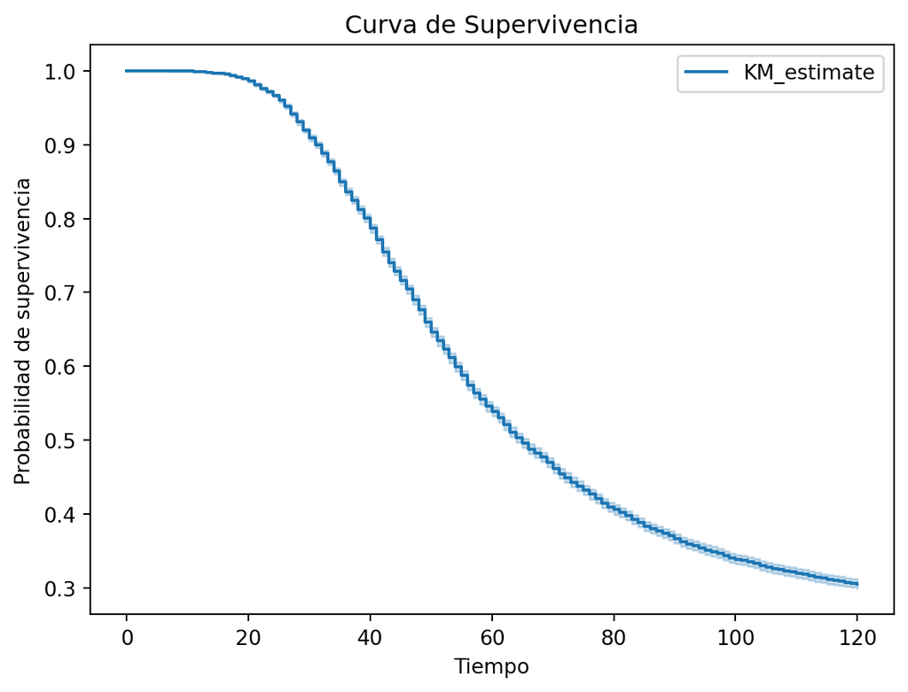

```
          removed  observed  censored  entrance  at_risk
event_at
0.0             1         1         0     22105    22105
2.0             2         2         0         0    22104
5.0             2         2         0         0    22102
6.0             1         1         0         0    22100
7.0             4         4         0         0    22099
```

```python
import pandas as pd
import numpy as np
from sklearn.model_selection import train_test_split
from sklearn.preprocessing import LabelEncoder
from xgboost import XGBClassifier
from sklearn.metrics import roc_auc_score
from lifelines import KaplanMeierFitter
from lifelines.utils import survival_table_from_events
import matplotlib.pyplot as plt

# Cargar los datos
# df_prep = pd.read_csv('ruta_a_tu_archivo.csv')

# Establecemos 'CHASIS' como índice
df = df_prep[['CHASIS', 'TIEMPO_MANT_1000', 'EVENTO_MANT_1000', 'CENSURA', 'AGENCIA', 'LINEA_NEGOCIO', 'FAMILIA_VH']]
df.set_index('CHASIS', inplace=True)

# Convertimos las variables categóricas usando Label Encoding
categorical_columns = ['AGENCIA', 'LINEA_NEGOCIO', 'FAMILIA_VH']
for col in categorical_columns:
    le = LabelEncoder()
    df[col] = le.fit_transform(df[col])

# Definimos la variable objetivo y las características
X = df[['AGENCIA', 'LINEA_NEGOCIO', 'FAMILIA_VH']]  # Características
y = df[['TIEMPO_MANT_1000', 'EVENTO_MANT_1000']]  # Tiempo y Evento

# Creamos un conjunto de entrenamiento y uno de prueba
X_train, X_test, y_train, y_test = train_test_split(X, y, test_size=0.2, random_state=42)

# Entrenamos el modelo XGBoost para la predicción de supervivencia
xgb_model = XGBClassifier(objective='binary:logistic', eval_metric='logloss')

# Ajustamos el modelo
xgb_model.fit(X_train, y_train['EVENTO_MANT_1000'])

# Realizamos la predicción en el conjunto de prueba
y_pred = xgb_model.predict(X_test)

# Evaluamos el desempeño del modelo usando ROC AUC
roc_auc = roc_auc_score(y_test['EVENTO_MANT_1000'], y_pred)
print(f"ROC AUC: {roc_auc}")

# Para el análisis de supervivencia, se puede realizar un análisis Kaplan-Meier
kmf = KaplanMeierFitter()
kmf.fit(durations=df['TIEMPO_MANT_1000'], event_observed=df['EVENTO_MANT_1000'])

# Graficamos la curva de supervivencia
kmf.plot_survival_function()
plt.title('Curva de Supervivencia')
plt.xlabel('Tiempo')
plt.ylabel('Probabilidad de supervivencia')
plt.show()

# Generamos la tabla de supervivencia
survival_table = survival_table_from_events(df['TIEMPO_MANT_1000'], df['EVENTO_MANT_1000'])
print(survival_table.head())
```